# Quick introduction to git

# Branching

- We can take the current state of files, and make diverging modifications without risk
  - Very common when working in teams
- Usually the default branch is named `main`
  - Thats where all the `main`s come from in previous commands

[figure not shown]

## Creating a new branch

```bash
$ git branch <branchname>
```

- At this point, `<branchname>` and `main` coincide perfectly. They will only start to diverge as we create new commit on it
- We can switch between branches with `git checkout`, e.g.

```bash
$ git checkout main
```

- This allows us to save as many “working states” as we want, no risk

## Basic merging

- We can rejoin our branches once we’re happy with changes
  - Achieved through `git merge`
- Git is smart and will (most of the time) figure out how to make a final version out of several

**Merges don’t always happen smoothly**

What happens when two branches changed the exact same thing in different ways?

## Let’s manufacture a merge conflict with soups

1. We start at `main` and branch-off to `soup-workshop`
2. In `soup-workshop` I decide my fav breakfast is *chilaquiles*

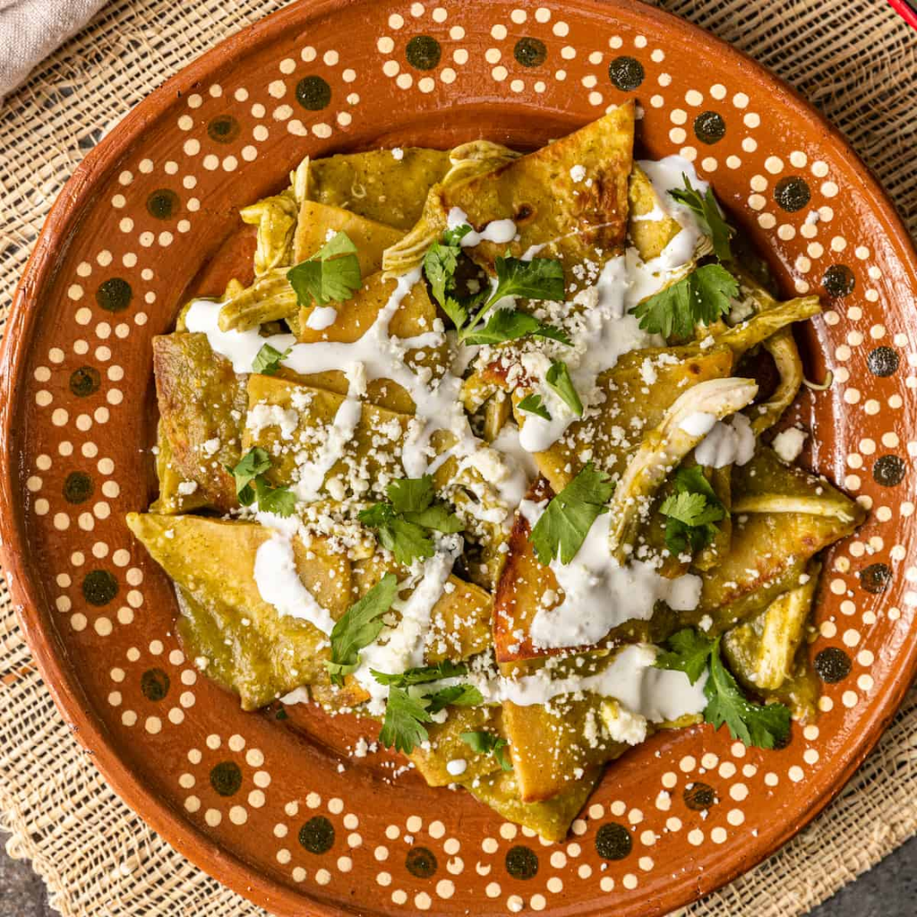

3. Back in `main` I correct to “eggs benedict”
4. What happens if I try to merge?

# Those are the basics :)

# References

Group Seminar

Chacon, Scott. n.d. *Pro Git*. Apress.